# **Differences in Squirrel Behavior by Fur Color in Central Park**

### **Glenn Schexnayder**

### **December 31, 2019**

- What?
  - Willingness to approach according to primary fur color.
- Where?
  - New York City's Central Park
- When?
  - October 2018
- Who?
  - Squirrel Census
- How?
  - Various volunteers, including student groups
- Why?
  - To determine what behaviors are different between subgroups of Eastern gray squirrels due to reports of squirrels being a nuisance in Central Park.

## What does the distribution of primary fur color for Eastern gray squirrels look like?

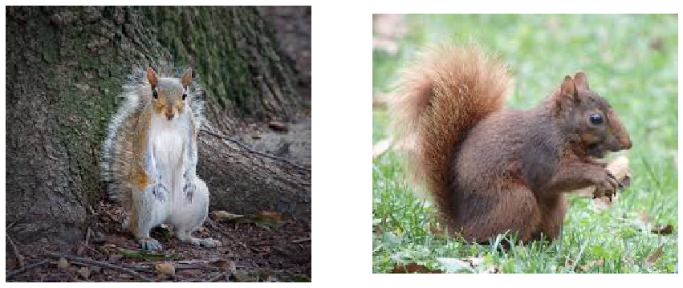

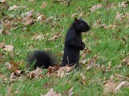

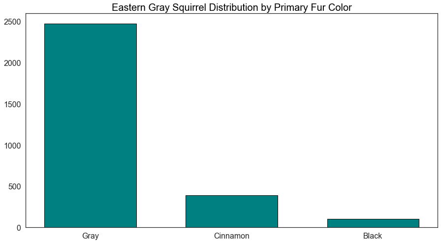

## What do the ratios of behaviors in each of these subgroups look like?

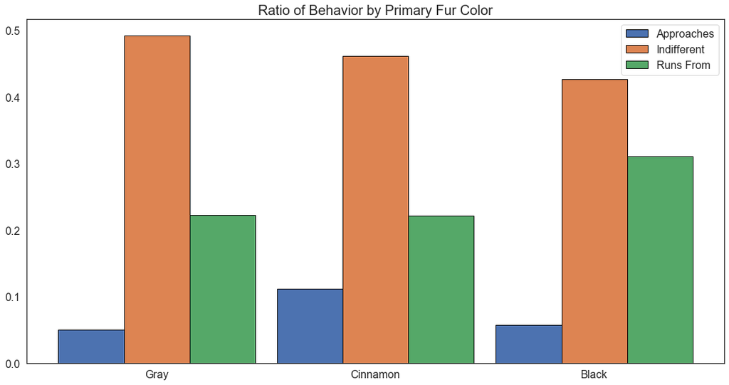

## Are these differences significant?

In most cases, no, but...

3 to 9 point difference at 95% confidence between gray-colored and cinnamon-colored squirrels as to whether they'll approach.